# Airbnb_8

price = cost per night

cleaning_fee: cleaning fee

extra_people: charge for having more than 1 person

property_type: type of accommodation (House, Apartment, etc.)

room_type:

Entire home/apt (guests have entire place to themselves) Private room (Guests have private room to sleep, all other rooms shared) Shared room (Guests sleep in room shared with others) number_of_reviews: Total number of reviews for the listing

review_scores_rating: Average review score (0 - 100)

longitude , latitude: geographical coordinates to help us locate the listing

neighbourhood*: three variables on a few major neighbourhoods in each city

```r
listings <- vroom("http://data.insideairbnb.com/denmark/hovedstaden/copenhagen/2020-06-26/data/listings.csv.gz") %>%
    #get the listings for Copenhagen
    clean_names()
```

[output not shown]

```
## Rows: 28,523
## Columns: 106
## $ id                                           <dbl> 6983, 26057, 26473, 29...
## $ listing_url                                  <chr> "https://www.airbnb.co...
## $ scrape_id                                    <dbl> 2.020063e+13, 2.020063...
## $ last_scraped                                 <date> 2020-06-28, 2020-06-2...
## $ name                                         <chr> "Copenhagen 'N Livin'"...
## $ summary                                      <chr> "Lovely apartment loca...
## $ space                                        <chr> "Beautiful and cosy ap...
## $ description                                  <chr> "Lovely apartment loca...
## $ experiences_offered                          <chr> "none", "none", "none"...
## $ neighborhood_overview                        <chr> "Nice bars and cozy ca...
## $ notes                                        <chr> NA, NA, NA, NA, "Pleas...
## $ transit                                      <chr> "Bus 66 runs to the ce...
## $ access                                       <chr> "Bedroom, living room,...
```

[output cut: 93 more lines]

Data summary

| Name | listings |
| --- | --- |
| Number of rows | 28523 |
| Number of columns | 106 |
| _______________________ |  |
| Column type frequency: |  |
| character | 45 |
| Date | 5 |
| logical | 16 |
| numeric | 40 |
| ________________________ |  |
| Group variables | None |

**Variable type: character**

| skim_variable | n_missing | complete_rate | min | max | empty | n_unique | whitespace |
| --- | --- | --- | --- | --- | --- | --- | --- |
| listing_url | 0 | 1.00 | 33 | 37 | 0 | 28523 | 0 |
| name | 57 | 1.00 | 1 | 211 | 0 | 26907 | 0 |
| summary | 1096 | 0.96 | 1 | 1000 | 0 | 26986 | 0 |
| space | 11390 | 0.60 | 1 | 1000 | 0 | 16806 | 0 |
| description | 515 | 0.98 | 1 | 1000 | 0 | 27748 | 0 |
| experiences_offered | 0 | 1.00 | 4 | 4 | 0 | 1 | 0 |
| neighborhood_overview | 12407 | 0.57 | 1 | 1000 | 0 | 15520 | 0 |
| notes | 20832 | 0.27 | 1 | 1000 | 0 | 7366 | 0 |
| transit | 11316 | 0.60 | 1 | 1000 | 0 | 16714 | 0 |
| access | 15751 | 0.45 | 1 | 1000 | 0 | 11251 | 0 |
| interaction | 14111 | 0.51 | 1 | 1000 | 0 | 13728 | 0 |
| house_rules | 13332 | 0.53 | 1 | 1000 | 0 | 13703 | 0 |
| picture_url | 0 | 1.00 | 81 | 146 | 0 | 28282 | 0 |
| host_url | 0 | 1.00 | 37 | 43 | 0 | 25745 | 0 |
| host_name | 12 | 1.00 | 1 | 34 | 0 | 6415 | 0 |
| host_location | 93 | 1.00 | 2 | 152 | 0 | 863 | 0 |
| host_about | 14028 | 0.51 | 1 | 3550 | 0 | 12478 | 34 |
| host_response_time | 11 | 1.00 | 3 | 18 | 0 | 5 | 0 |
| host_response_rate | 11 | 1.00 | 2 | 4 | 0 | 44 | 0 |
| host_acceptance_rate | 11 | 1.00 | 2 | 4 | 0 | 100 | 0 |
| host_thumbnail_url | 11 | 1.00 | 55 | 106 | 0 | 25669 | 0 |
| host_picture_url | 11 | 1.00 | 57 | 109 | 0 | 25669 | 0 |
| host_neighbourhood | 8007 | 0.72 | 1 | 21 | 0 | 56 | 0 |
| host_verifications | 0 | 1.00 | 2 | 156 | 0 | 316 | 0 |
| street | 0 | 1.00 | 10 | 61 | 0 | 528 | 0 |
| neighbourhood | 0 | 1.00 | 5 | 14 | 0 | 21 | 0 |
| neighbourhood_cleansed | 0 | 1.00 | 5 | 25 | 0 | 11 | 0 |
| city | 13 | 1.00 | 1 | 26 | 0 | 136 | 0 |
| state | 24042 | 0.16 | 1 | 25 | 0 | 170 | 0 |
| market | 864 | 0.97 | 6 | 21 | 0 | 10 | 0 |
| smart_location | 0 | 1.00 | 10 | 35 | 0 | 158 | 0 |
| country_code | 0 | 1.00 | 2 | 2 | 0 | 1 | 0 |
| country | 0 | 1.00 | 7 | 7 | 0 | 1 | 0 |
| property_type | 0 | 1.00 | 3 | 22 | 0 | 29 | 0 |
| room_type | 0 | 1.00 | 10 | 15 | 0 | 4 | 0 |
| bed_type | 0 | 1.00 | 5 | 13 | 0 | 5 | 0 |
| amenities | 0 | 1.00 | 2 | 1179 | 0 | 26634 | 0 |
| price | 0 | 1.00 | 5 | 10 | 0 | 611 | 0 |
| weekly_price | 25008 | 0.12 | 7 | 11 | 0 | 718 | 0 |
| monthly_price | 26971 | 0.05 | 7 | 11 | 0 | 476 | 0 |
| security_deposit | 13845 | 0.51 | 5 | 10 | 0 | 386 | 0 |
| cleaning_fee | 8968 | 0.69 | 5 | 9 | 0 | 430 | 0 |
| extra_people | 0 | 1.00 | 5 | 9 | 0 | 265 | 0 |
| calendar_updated | 0 | 1.00 | 5 | 13 | 0 | 82 | 0 |
| cancellation_policy | 0 | 1.00 | 8 | 27 | 0 | 4 | 0 |

**Variable type: Date**

| skim_variable | n_missing | complete_rate | min | max | median | n_unique |
| --- | --- | --- | --- | --- | --- | --- |
| last_scraped | 0 | 1.00 | 2020-06-26 | 2020-06-30 | 2020-06-27 | 5 |
| host_since | 11 | 1.00 | 2008-06-27 | 2020-06-26 | 2015-06-22 | 3379 |
| calendar_last_scraped | 0 | 1.00 | 2020-06-26 | 2020-06-30 | 2020-06-27 | 5 |
| first_review | 4968 | 0.83 | 2009-09-04 | 2020-06-28 | 2017-08-07 | 2582 |
| last_review | 4968 | 0.83 | 2011-08-10 | 2020-06-28 | 2019-07-29 | 1846 |

**Variable type: logical**

| skim_variable | n_missing | complete_rate | mean | count |
| --- | --- | --- | --- | --- |
| thumbnail_url | 28523 | 0 | NaN | : |
| medium_url | 28523 | 0 | NaN | : |
| xl_picture_url | 28523 | 0 | NaN | : |
| host_is_superhost | 11 | 1 | 0.10 | FAL: 25610, TRU: 2902 |
| host_has_profile_pic | 11 | 1 | 1.00 | TRU: 28445, FAL: 67 |
| host_identity_verified | 11 | 1 | 0.38 | FAL: 17790, TRU: 10722 |
| neighbourhood_group_cleansed | 28523 | 0 | NaN | : |
| is_location_exact | 0 | 1 | 0.79 | TRU: 22507, FAL: 6016 |
| has_availability | 0 | 1 | 1.00 | TRU: 28523 |
| requires_license | 0 | 1 | 0.00 | FAL: 28523 |
| license | 28523 | 0 | NaN | : |
| jurisdiction_names | 28523 | 0 | NaN | : |
| instant_bookable | 0 | 1 | 0.29 | FAL: 20360, TRU: 8163 |
| is_business_travel_ready | 0 | 1 | 0.00 | FAL: 28523 |
| require_guest_profile_picture | 0 | 1 | 0.01 | FAL: 28379, TRU: 144 |
| require_guest_phone_verification | 0 | 1 | 0.01 | FAL: 28327, TRU: 196 |

**Variable type: numeric**

| skim_variable | n_missing | complete_rate | mean | sd | p0 | p25 | p50 | p75 | p100 | hist |
| --- | --- | --- | --- | --- | --- | --- | --- | --- | --- | --- |
| id | 0 | 1.00 | 2.044063e+07 | 12261143.29 | 6.983000e+03 | 1.008379e+07 | 1.950297e+07 | 3.043587e+07 | 4.395635e+07 | ▇▇▇▅▆ |
| scrape_id | 0 | 1.00 | 2.020063e+13 | 0.00 | 2.020063e+13 | 2.020063e+13 | 2.020063e+13 | 2.020063e+13 | 2.020063e+13 | ▁▁▇▁▁ |
| host_id | 0 | 1.00 | 6.731400e+07 | 76172316.22 | 5.130000e+02 | 1.281774e+07 | 3.604205e+07 | 9.463162e+07 | 3.519509e+08 | ▇▂▁▁▁ |
| host_listings_count | 11 | 1.00 | 5.460000e+00 | 34.32 | 0.000000e+00 | 1.000000e+00 | 1.000000e+00 | 1.000000e+00 | 7.370000e+02 | ▇▁▁▁▁ |
| host_total_listings_count | 11 | 1.00 | 5.460000e+00 | 34.32 | 0.000000e+00 | 1.000000e+00 | 1.000000e+00 | 1.000000e+00 | 7.370000e+02 | ▇▁▁▁▁ |
| zipcode | 815 | 0.97 | 2.069760e+03 | 390.81 | 2.000000e+01 | 1.855750e+03 | 2.200000e+03 | 2.300000e+03 | 2.100000e+04 | ▇▁▁▁▁ |
| latitude | 0 | 1.00 | 5.568000e+01 | 0.02 | 5.562000e+01 | 5.567000e+01 | 5.568000e+01 | 5.570000e+01 | 5.573000e+01 | ▁▃▇▇▁ |
| longitude | 0 | 1.00 | 1.256000e+01 | 0.03 | 1.245000e+01 | 1.254000e+01 | 1.255000e+01 | 1.258000e+01 | 1.264000e+01 | ▁▂▇▅▂ |
| accommodates | 0 | 1.00 | 3.320000e+00 | 1.63 | 1.000000e+00 | 2.000000e+00 | 3.000000e+00 | 4.000000e+00 | 1.600000e+01 | ▇▂▁▁▁ |
| bathrooms | 12 | 1.00 | 1.080000e+00 | 0.28 | 0.000000e+00 | 1.000000e+00 | 1.000000e+00 | 1.000000e+00 | 1.000000e+01 | ▇▁▁▁▁ |
| bedrooms | 29 | 1.00 | 1.550000e+00 | 1.06 | 0.000000e+00 | 1.000000e+00 | 1.000000e+00 | 2.000000e+00 | 1.010000e+02 | ▇▁▁▁▁ |
| beds | 103 | 1.00 | 2.040000e+00 | 1.44 | 0.000000e+00 | 1.000000e+00 | 2.000000e+00 | 3.000000e+00 | 2.500000e+01 | ▇▁▁▁▁ |
| square_feet | 28130 | 0.01 | 7.218900e+02 | 576.10 | 0.000000e+00 | 1.200000e+02 | 7.640000e+02 | 1.076000e+03 | 2.799000e+03 | ▇▇▃▁▁ |
| guests_included | 0 | 1.00 | 1.520000e+00 | 1.06 | 1.000000e+00 | 1.000000e+00 | 1.000000e+00 | 2.000000e+00 | 1.600000e+01 | ▇▁▁▁▁ |
| minimum_nights | 0 | 1.00 | 3.850000e+00 | 18.07 | 1.000000e+00 | 2.000000e+00 | 3.000000e+00 | 4.000000e+00 | 1.100000e+03 | ▇▁▁▁▁ |
| maximum_nights | 0 | 1.00 | 6.206700e+02 | 553.19 | 1.000000e+00 | 1.500000e+01 | 1.125000e+03 | 1.125000e+03 | 9.999000e+03 | ▇▁▁▁▁ |
| minimum_minimum_nights | 0 | 1.00 | 3.840000e+00 | 18.08 | 1.000000e+00 | 2.000000e+00 | 3.000000e+00 | 4.000000e+00 | 1.100000e+03 | ▇▁▁▁▁ |
| maximum_minimum_nights | 0 | 1.00 | 4.120000e+00 | 19.29 | 1.000000e+00 | 2.000000e+00 | 3.000000e+00 | 4.000000e+00 | 1.100000e+03 | ▇▁▁▁▁ |
| minimum_maximum_nights | 0 | 1.00 | 6.669200e+02 | 548.00 | 1.000000e+00 | 2.000000e+01 | 1.125000e+03 | 1.125000e+03 | 9.999000e+03 | ▇▁▁▁▁ |
| maximum_maximum_nights | 0 | 1.00 | 6.703800e+02 | 547.39 | 1.000000e+00 | 2.000000e+01 | 1.125000e+03 | 1.125000e+03 | 9.999000e+03 | ▇▁▁▁▁ |
| minimum_nights_avg_ntm | 0 | 1.00 | 3.970000e+00 | 18.35 | 1.000000e+00 | 2.000000e+00 | 3.000000e+00 | 4.000000e+00 | 1.100000e+03 | ▇▁▁▁▁ |
| maximum_nights_avg_ntm | 0 | 1.00 | 6.684100e+02 | 547.20 | 1.000000e+00 | 2.000000e+01 | 1.125000e+03 | 1.125000e+03 | 9.999000e+03 | ▇▁▁▁▁ |
| availability_30 | 0 | 1.00 | 5.870000e+00 | 10.42 | 0.000000e+00 | 0.000000e+00 | 0.000000e+00 | 8.000000e+00 | 3.000000e+01 | ▇▁▁▁▂ |
| availability_60 | 0 | 1.00 | 1.124000e+01 | 20.15 | 0.000000e+00 | 0.000000e+00 | 0.000000e+00 | 1.400000e+01 | 6.000000e+01 | ▇▁▁▁▂ |
| availability_90 | 0 | 1.00 | 1.649000e+01 | 29.99 | 0.000000e+00 | 0.000000e+00 | 0.000000e+00 | 1.800000e+01 | 9.000000e+01 | ▇▁▁▁▁ |
| availability_365 | 0 | 1.00 | 4.947000e+01 | 99.23 | 0.000000e+00 | 0.000000e+00 | 0.000000e+00 | 3.500000e+01 | 3.650000e+02 | ▇▁▁▁▁ |
| number_of_reviews | 0 | 1.00 | 1.357000e+01 | 27.09 | 0.000000e+00 | 1.000000e+00 | 5.000000e+00 | 1.500000e+01 | 6.370000e+02 | ▇▁▁▁▁ |
| number_of_reviews_ltm | 0 | 1.00 | 2.740000e+00 | 6.64 | 0.000000e+00 | 0.000000e+00 | 0.000000e+00 | 3.000000e+00 | 3.760000e+02 | ▇▁▁▁▁ |
| review_scores_rating | 5447 | 0.81 | 9.516000e+01 | 6.83 | 2.000000e+01 | 9.300000e+01 | 9.700000e+01 | 1.000000e+02 | 1.000000e+02 | ▁▁▁▁▇ |
| review_scores_accuracy | 5468 | 0.81 | 9.730000e+00 | 0.66 | 2.000000e+00 | 1.000000e+01 | 1.000000e+01 | 1.000000e+01 | 1.000000e+01 | ▁▁▁▁▇ |
| review_scores_cleanliness | 5466 | 0.81 | 9.380000e+00 | 0.96 | 2.000000e+00 | 9.000000e+00 | 1.000000e+01 | 1.000000e+01 | 1.000000e+01 | ▁▁▁▁▇ |
| review_scores_checkin | 5488 | 0.81 | 9.820000e+00 | 0.56 | 2.000000e+00 | 1.000000e+01 | 1.000000e+01 | 1.000000e+01 | 1.000000e+01 | ▁▁▁▁▇ |
| review_scores_communication | 5470 | 0.81 | 9.860000e+00 | 0.53 | 2.000000e+00 | 1.000000e+01 | 1.000000e+01 | 1.000000e+01 | 1.000000e+01 | ▁▁▁▁▇ |
| review_scores_location | 5491 | 0.81 | 9.600000e+00 | 0.68 | 2.000000e+00 | 9.000000e+00 | 1.000000e+01 | 1.000000e+01 | 1.000000e+01 | ▁▁▁▁▇ |
| review_scores_value | 5495 | 0.81 | 9.450000e+00 | 0.76 | 2.000000e+00 | 9.000000e+00 | 1.000000e+01 | 1.000000e+01 | 1.000000e+01 | ▁▁▁▁▇ |
| calculated_host_listings_count | 0 | 1.00 | 4.450000e+00 | 28.06 | 1.000000e+00 | 1.000000e+00 | 1.000000e+00 | 1.000000e+00 | 2.810000e+02 | ▇▁▁▁▁ |
| calculated_host_listings_count_entire_homes | 0 | 1.00 | 4.170000e+00 | 28.08 | 0.000000e+00 | 1.000000e+00 | 1.000000e+00 | 1.000000e+00 | 2.810000e+02 | ▇▁▁▁▁ |
| calculated_host_listings_count_private_rooms | 0 | 1.00 | 2.600000e-01 | 0.73 | 0.000000e+00 | 0.000000e+00 | 0.000000e+00 | 0.000000e+00 | 1.200000e+01 | ▇▁▁▁▁ |
| calculated_host_listings_count_shared_rooms | 0 | 1.00 | 1.000000e-02 | 0.33 | 0.000000e+00 | 0.000000e+00 | 0.000000e+00 | 0.000000e+00 | 1.300000e+01 | ▇▁▁▁▁ |
| reviews_per_month | 4968 | 0.83 | 4.900000e-01 | 0.73 | 1.000000e-02 | 1.200000e-01 | 2.800000e-01 | 5.900000e-01 | 3.065000e+01 | ▇▁▁▁▁ |

#EDA

We tried first to convert some of the data from characters to numeric (i.e “$176.00”–. 176)

| property_type | count |
| --- | --- |
| Apartment | 23942 |
| Condominium | 1673 |
| House | 1365 |
| Townhouse | 554 |
| Serviced apartment | 331 |
| Loft | 231 |
| Villa | 190 |
| Hostel | 28 |
| Guesthouse | 23 |
| Bungalow | 22 |
| Guest suite | 22 |
| Bed and breakfast | 21 |
| Houseboat | 21 |
| Boat | 20 |
| Hotel | 20 |
| Other | 14 |
| Tiny house | 14 |
| Cabin | 10 |
| Boutique hotel | 5 |
| Cottage | 4 |
| Hut | 3 |
| Aparthotel | 2 |
| Barn | 2 |
| Camper/RV | 1 |
| Casa particular (Cuba) | 1 |
| Earth house | 1 |
| Island | 1 |
| Lighthouse | 1 |
| Tent | 1 |

Table: Data summary

| Name | listings |
| --- | --- |
| Number of rows | 28523 |
| Number of columns | 107 |
| _______________________ |  |
| Column type frequency: |  |
| character | 43 |
| Date | 5 |
| logical | 16 |
| numeric | 43 |
| ________________________ |  |
| Group variables | None |

**Variable type: character**

| skim_variable | n_missing | complete_rate | min | max | empty | n_unique | whitespace |
| --- | --- | --- | --- | --- | --- | --- | --- |
| listing_url | 0 | 1.00 | 33 | 37 | 0 | 28523 | 0 |
| name | 57 | 1.00 | 1 | 211 | 0 | 26907 | 0 |
| summary | 1096 | 0.96 | 1 | 1000 | 0 | 26986 | 0 |
| space | 11390 | 0.60 | 1 | 1000 | 0 | 16806 | 0 |
| description | 515 | 0.98 | 1 | 1000 | 0 | 27748 | 0 |
| experiences_offered | 0 | 1.00 | 4 | 4 | 0 | 1 | 0 |
| neighborhood_overview | 12407 | 0.57 | 1 | 1000 | 0 | 15520 | 0 |
| notes | 20832 | 0.27 | 1 | 1000 | 0 | 7366 | 0 |
| transit | 11316 | 0.60 | 1 | 1000 | 0 | 16714 | 0 |
| access | 15751 | 0.45 | 1 | 1000 | 0 | 11251 | 0 |
| interaction | 14111 | 0.51 | 1 | 1000 | 0 | 13728 | 0 |
| house_rules | 13332 | 0.53 | 1 | 1000 | 0 | 13703 | 0 |
| picture_url | 0 | 1.00 | 81 | 146 | 0 | 28282 | 0 |
| host_url | 0 | 1.00 | 37 | 43 | 0 | 25745 | 0 |
| host_name | 12 | 1.00 | 1 | 34 | 0 | 6415 | 0 |
| host_location | 93 | 1.00 | 2 | 152 | 0 | 863 | 0 |
| host_about | 14028 | 0.51 | 1 | 3550 | 0 | 12478 | 34 |
| host_response_time | 11 | 1.00 | 3 | 18 | 0 | 5 | 0 |
| host_response_rate | 11 | 1.00 | 2 | 4 | 0 | 44 | 0 |
| host_acceptance_rate | 11 | 1.00 | 2 | 4 | 0 | 100 | 0 |
| host_thumbnail_url | 11 | 1.00 | 55 | 106 | 0 | 25669 | 0 |
| host_picture_url | 11 | 1.00 | 57 | 109 | 0 | 25669 | 0 |
| host_neighbourhood | 8007 | 0.72 | 1 | 21 | 0 | 56 | 0 |
| host_verifications | 0 | 1.00 | 2 | 156 | 0 | 316 | 0 |
| street | 0 | 1.00 | 10 | 61 | 0 | 528 | 0 |
| neighbourhood | 0 | 1.00 | 5 | 14 | 0 | 21 | 0 |
| neighbourhood_cleansed | 0 | 1.00 | 5 | 25 | 0 | 11 | 0 |
| city | 13 | 1.00 | 1 | 26 | 0 | 136 | 0 |
| state | 24042 | 0.16 | 1 | 25 | 0 | 170 | 0 |
| market | 864 | 0.97 | 6 | 21 | 0 | 10 | 0 |
| smart_location | 0 | 1.00 | 10 | 35 | 0 | 158 | 0 |
| country_code | 0 | 1.00 | 2 | 2 | 0 | 1 | 0 |
| country | 0 | 1.00 | 7 | 7 | 0 | 1 | 0 |
| property_type | 0 | 1.00 | 3 | 22 | 0 | 29 | 0 |
| room_type | 0 | 1.00 | 10 | 15 | 0 | 4 | 0 |
| bed_type | 0 | 1.00 | 5 | 13 | 0 | 5 | 0 |
| amenities | 0 | 1.00 | 2 | 1179 | 0 | 26634 | 0 |
| weekly_price | 25008 | 0.12 | 7 | 11 | 0 | 718 | 0 |
| monthly_price | 26971 | 0.05 | 7 | 11 | 0 | 476 | 0 |
| security_deposit | 13845 | 0.51 | 5 | 10 | 0 | 386 | 0 |
| calendar_updated | 0 | 1.00 | 5 | 13 | 0 | 82 | 0 |
| cancellation_policy | 0 | 1.00 | 8 | 27 | 0 | 4 | 0 |
| prop_type_simplified | 0 | 1.00 | 5 | 11 | 0 | 5 | 0 |

**Variable type: Date**

| skim_variable | n_missing | complete_rate | min | max | median | n_unique |
| --- | --- | --- | --- | --- | --- | --- |
| last_scraped | 0 | 1.00 | 2020-06-26 | 2020-06-30 | 2020-06-27 | 5 |
| host_since | 11 | 1.00 | 2008-06-27 | 2020-06-26 | 2015-06-22 | 3379 |
| calendar_last_scraped | 0 | 1.00 | 2020-06-26 | 2020-06-30 | 2020-06-27 | 5 |
| first_review | 4968 | 0.83 | 2009-09-04 | 2020-06-28 | 2017-08-07 | 2582 |
| last_review | 4968 | 0.83 | 2011-08-10 | 2020-06-28 | 2019-07-29 | 1846 |

**Variable type: logical**

| skim_variable | n_missing | complete_rate | mean | count |
| --- | --- | --- | --- | --- |
| thumbnail_url | 28523 | 0 | NaN | : |
| medium_url | 28523 | 0 | NaN | : |
| xl_picture_url | 28523 | 0 | NaN | : |
| host_is_superhost | 11 | 1 | 0.10 | FAL: 25610, TRU: 2902 |
| host_has_profile_pic | 11 | 1 | 1.00 | TRU: 28445, FAL: 67 |
| host_identity_verified | 11 | 1 | 0.38 | FAL: 17790, TRU: 10722 |
| neighbourhood_group_cleansed | 28523 | 0 | NaN | : |
| is_location_exact | 0 | 1 | 0.79 | TRU: 22507, FAL: 6016 |
| has_availability | 0 | 1 | 1.00 | TRU: 28523 |
| requires_license | 0 | 1 | 0.00 | FAL: 28523 |
| license | 28523 | 0 | NaN | : |
| jurisdiction_names | 28523 | 0 | NaN | : |
| instant_bookable | 0 | 1 | 0.29 | FAL: 20360, TRU: 8163 |
| is_business_travel_ready | 0 | 1 | 0.00 | FAL: 28523 |
| require_guest_profile_picture | 0 | 1 | 0.01 | FAL: 28379, TRU: 144 |
| require_guest_phone_verification | 0 | 1 | 0.01 | FAL: 28327, TRU: 196 |

**Variable type: numeric**

| skim_variable | n_missing | complete_rate | mean | sd | p0 | p25 | p50 | p75 | p100 | hist |
| --- | --- | --- | --- | --- | --- | --- | --- | --- | --- | --- |
| id | 0 | 1.00 | 2.044063e+07 | 12261143.29 | 6.983000e+03 | 1.008379e+07 | 1.950297e+07 | 3.043587e+07 | 4.395635e+07 | ▇▇▇▅▆ |
| scrape_id | 0 | 1.00 | 2.020063e+13 | 0.00 | 2.020063e+13 | 2.020063e+13 | 2.020063e+13 | 2.020063e+13 | 2.020063e+13 | ▁▁▇▁▁ |
| host_id | 0 | 1.00 | 6.731400e+07 | 76172316.22 | 5.130000e+02 | 1.281774e+07 | 3.604205e+07 | 9.463162e+07 | 3.519509e+08 | ▇▂▁▁▁ |
| host_listings_count | 11 | 1.00 | 5.460000e+00 | 34.32 | 0.000000e+00 | 1.000000e+00 | 1.000000e+00 | 1.000000e+00 | 7.370000e+02 | ▇▁▁▁▁ |
| host_total_listings_count | 11 | 1.00 | 5.460000e+00 | 34.32 | 0.000000e+00 | 1.000000e+00 | 1.000000e+00 | 1.000000e+00 | 7.370000e+02 | ▇▁▁▁▁ |
| zipcode | 815 | 0.97 | 2.069760e+03 | 390.81 | 2.000000e+01 | 1.855750e+03 | 2.200000e+03 | 2.300000e+03 | 2.100000e+04 | ▇▁▁▁▁ |
| latitude | 0 | 1.00 | 5.568000e+01 | 0.02 | 5.562000e+01 | 5.567000e+01 | 5.568000e+01 | 5.570000e+01 | 5.573000e+01 | ▁▃▇▇▁ |
| longitude | 0 | 1.00 | 1.256000e+01 | 0.03 | 1.245000e+01 | 1.254000e+01 | 1.255000e+01 | 1.258000e+01 | 1.264000e+01 | ▁▂▇▅▂ |
| accommodates | 0 | 1.00 | 3.320000e+00 | 1.63 | 1.000000e+00 | 2.000000e+00 | 3.000000e+00 | 4.000000e+00 | 1.600000e+01 | ▇▂▁▁▁ |
| bathrooms | 12 | 1.00 | 1.080000e+00 | 0.28 | 0.000000e+00 | 1.000000e+00 | 1.000000e+00 | 1.000000e+00 | 1.000000e+01 | ▇▁▁▁▁ |
| bedrooms | 29 | 1.00 | 1.550000e+00 | 1.06 | 0.000000e+00 | 1.000000e+00 | 1.000000e+00 | 2.000000e+00 | 1.010000e+02 | ▇▁▁▁▁ |
| beds | 103 | 1.00 | 2.040000e+00 | 1.44 | 0.000000e+00 | 1.000000e+00 | 2.000000e+00 | 3.000000e+00 | 2.500000e+01 | ▇▁▁▁▁ |
| square_feet | 28130 | 0.01 | 7.218900e+02 | 576.10 | 0.000000e+00 | 1.200000e+02 | 7.640000e+02 | 1.076000e+03 | 2.799000e+03 | ▇▇▃▁▁ |
| price | 0 | 1.00 | 8.491900e+02 | 1066.81 | 0.000000e+00 | 4.980000e+02 | 6.980000e+02 | 9.960000e+02 | 6.917500e+04 | ▇▁▁▁▁ |
| cleaning_fee | 0 | 1.00 | 2.103900e+02 | 249.69 | 0.000000e+00 | 0.000000e+00 | 1.500000e+02 | 3.000000e+02 | 4.000000e+03 | ▇▁▁▁▁ |
| guests_included | 0 | 1.00 | 1.520000e+00 | 1.06 | 1.000000e+00 | 1.000000e+00 | 1.000000e+00 | 2.000000e+00 | 1.600000e+01 | ▇▁▁▁▁ |
| extra_people | 0 | 1.00 | 6.388000e+01 | 126.23 | 0.000000e+00 | 0.000000e+00 | 0.000000e+00 | 1.000000e+02 | 2.024000e+03 | ▇▁▁▁▁ |
| minimum_nights | 0 | 1.00 | 3.850000e+00 | 18.07 | 1.000000e+00 | 2.000000e+00 | 3.000000e+00 | 4.000000e+00 | 1.100000e+03 | ▇▁▁▁▁ |
| maximum_nights | 0 | 1.00 | 6.206700e+02 | 553.19 | 1.000000e+00 | 1.500000e+01 | 1.125000e+03 | 1.125000e+03 | 9.999000e+03 | ▇▁▁▁▁ |
| minimum_minimum_nights | 0 | 1.00 | 3.840000e+00 | 18.08 | 1.000000e+00 | 2.000000e+00 | 3.000000e+00 | 4.000000e+00 | 1.100000e+03 | ▇▁▁▁▁ |
| maximum_minimum_nights | 0 | 1.00 | 4.120000e+00 | 19.29 | 1.000000e+00 | 2.000000e+00 | 3.000000e+00 | 4.000000e+00 | 1.100000e+03 | ▇▁▁▁▁ |
| minimum_maximum_nights | 0 | 1.00 | 6.669200e+02 | 548.00 | 1.000000e+00 | 2.000000e+01 | 1.125000e+03 | 1.125000e+03 | 9.999000e+03 | ▇▁▁▁▁ |
| maximum_maximum_nights | 0 | 1.00 | 6.703800e+02 | 547.39 | 1.000000e+00 | 2.000000e+01 | 1.125000e+03 | 1.125000e+03 | 9.999000e+03 | ▇▁▁▁▁ |
| minimum_nights_avg_ntm | 0 | 1.00 | 3.970000e+00 | 18.35 | 1.000000e+00 | 2.000000e+00 | 3.000000e+00 | 4.000000e+00 | 1.100000e+03 | ▇▁▁▁▁ |
| maximum_nights_avg_ntm | 0 | 1.00 | 6.684100e+02 | 547.20 | 1.000000e+00 | 2.000000e+01 | 1.125000e+03 | 1.125000e+03 | 9.999000e+03 | ▇▁▁▁▁ |
| availability_30 | 0 | 1.00 | 5.870000e+00 | 10.42 | 0.000000e+00 | 0.000000e+00 | 0.000000e+00 | 8.000000e+00 | 3.000000e+01 | ▇▁▁▁▂ |
| availability_60 | 0 | 1.00 | 1.124000e+01 | 20.15 | 0.000000e+00 | 0.000000e+00 | 0.000000e+00 | 1.400000e+01 | 6.000000e+01 | ▇▁▁▁▂ |
| availability_90 | 0 | 1.00 | 1.649000e+01 | 29.99 | 0.000000e+00 | 0.000000e+00 | 0.000000e+00 | 1.800000e+01 | 9.000000e+01 | ▇▁▁▁▁ |
| availability_365 | 0 | 1.00 | 4.947000e+01 | 99.23 | 0.000000e+00 | 0.000000e+00 | 0.000000e+00 | 3.500000e+01 | 3.650000e+02 | ▇▁▁▁▁ |
| number_of_reviews | 0 | 1.00 | 1.357000e+01 | 27.09 | 0.000000e+00 | 1.000000e+00 | 5.000000e+00 | 1.500000e+01 | 6.370000e+02 | ▇▁▁▁▁ |
| number_of_reviews_ltm | 0 | 1.00 | 2.740000e+00 | 6.64 | 0.000000e+00 | 0.000000e+00 | 0.000000e+00 | 3.000000e+00 | 3.760000e+02 | ▇▁▁▁▁ |
| review_scores_rating | 5447 | 0.81 | 9.516000e+01 | 6.83 | 2.000000e+01 | 9.300000e+01 | 9.700000e+01 | 1.000000e+02 | 1.000000e+02 | ▁▁▁▁▇ |
| review_scores_accuracy | 5468 | 0.81 | 9.730000e+00 | 0.66 | 2.000000e+00 | 1.000000e+01 | 1.000000e+01 | 1.000000e+01 | 1.000000e+01 | ▁▁▁▁▇ |
| review_scores_cleanliness | 5466 | 0.81 | 9.380000e+00 | 0.96 | 2.000000e+00 | 9.000000e+00 | 1.000000e+01 | 1.000000e+01 | 1.000000e+01 | ▁▁▁▁▇ |
| review_scores_checkin | 5488 | 0.81 | 9.820000e+00 | 0.56 | 2.000000e+00 | 1.000000e+01 | 1.000000e+01 | 1.000000e+01 | 1.000000e+01 | ▁▁▁▁▇ |
| review_scores_communication | 5470 | 0.81 | 9.860000e+00 | 0.53 | 2.000000e+00 | 1.000000e+01 | 1.000000e+01 | 1.000000e+01 | 1.000000e+01 | ▁▁▁▁▇ |
| review_scores_location | 5491 | 0.81 | 9.600000e+00 | 0.68 | 2.000000e+00 | 9.000000e+00 | 1.000000e+01 | 1.000000e+01 | 1.000000e+01 | ▁▁▁▁▇ |
| review_scores_value | 5495 | 0.81 | 9.450000e+00 | 0.76 | 2.000000e+00 | 9.000000e+00 | 1.000000e+01 | 1.000000e+01 | 1.000000e+01 | ▁▁▁▁▇ |
| calculated_host_listings_count | 0 | 1.00 | 4.450000e+00 | 28.06 | 1.000000e+00 | 1.000000e+00 | 1.000000e+00 | 1.000000e+00 | 2.810000e+02 | ▇▁▁▁▁ |
| calculated_host_listings_count_entire_homes | 0 | 1.00 | 4.170000e+00 | 28.08 | 0.000000e+00 | 1.000000e+00 | 1.000000e+00 | 1.000000e+00 | 2.810000e+02 | ▇▁▁▁▁ |
| calculated_host_listings_count_private_rooms | 0 | 1.00 | 2.600000e-01 | 0.73 | 0.000000e+00 | 0.000000e+00 | 0.000000e+00 | 0.000000e+00 | 1.200000e+01 | ▇▁▁▁▁ |
| calculated_host_listings_count_shared_rooms | 0 | 1.00 | 1.000000e-02 | 0.33 | 0.000000e+00 | 0.000000e+00 | 0.000000e+00 | 0.000000e+00 | 1.300000e+01 | ▇▁▁▁▁ |
| reviews_per_month | 4968 | 0.83 | 4.900000e-01 | 0.73 | 1.000000e-02 | 1.200000e-01 | 2.800000e-01 | 5.900000e-01 | 3.065000e+01 | ▇▁▁▁▁ |

| minimum_nights | count |
| --- | --- |
| 2 | 8500 |
| 3 | 6479 |
| 1 | 5444 |
| 4 | 3117 |
| 5 | 2346 |
| 7 | 997 |
| 6 | 702 |
| 14 | 198 |
| 10 | 170 |
| 30 | 136 |
| 8 | 52 |
| 20 | 49 |
| 15 | 35 |
| 21 | 33 |
| 60 | 23 |
| 9 | 22 |
| 12 | 21 |
| 90 | 21 |
| 13 | 20 |
| 25 | 16 |
| 28 | 14 |
| 50 | 14 |
| 100 | 8 |
| 31 | 7 |
| 11 | 6 |
| 23 | 6 |
| 29 | 6 |
| 45 | 5 |
| 16 | 4 |
| 19 | 4 |
| 200 | 4 |
| 1e+03 | 4 |
| 17 | 3 |
| 40 | 3 |
| 70 | 3 |
| 80 | 3 |
| 120 | 3 |
| 18 | 2 |
| 22 | 2 |
| 24 | 2 |
| 26 | 2 |
| 27 | 2 |
| 49 | 2 |
| 85 | 2 |
| 160 | 2 |
| 180 | 2 |
| 360 | 2 |
| 365 | 2 |
| 999 | 2 |
| 34 | 1 |
| 35 | 1 |
| 39 | 1 |
| 42 | 1 |
| 43 | 1 |
| 48 | 1 |
| 56 | 1 |
| 59 | 1 |
| 61 | 1 |
| 66 | 1 |
| 75 | 1 |
| 89 | 1 |
| 92 | 1 |
| 102 | 1 |
| 107 | 1 |
| 150 | 1 |
| 270 | 1 |
| 300 | 1 |
| 430 | 1 |
| 500 | 1 |
| 1.1e+03 | 1 |

> The most common values are 2,3,1,4,5.That means renting for a five days or less. We see that there is a dramatic decrease of the number of listing from 5 days and above and this may be due to the fact that people staying for lomger periods are not here for travel purposes but for other reasons such as work, living etc.

[interactive chart not shown]

```r
#Calculated median price per night for each property type
average_per_proptype <- listings_filtered_4nights %>%
  group_by(prop_type_simplified) %>%
  summarise(median_price = median(price))
```

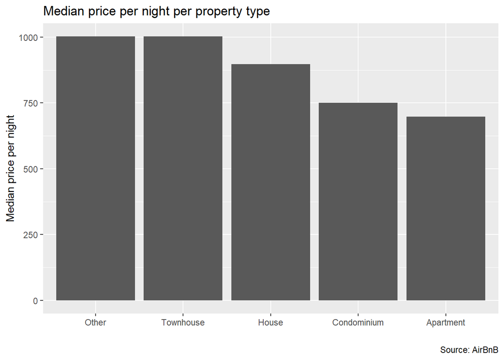

```r
#Plotted a bar chart with median price per night for each property type
average_per_proptype %>%
  ggplot(aes(
    x = reorder(prop_type_simplified, desc(median_price)),
    y = median_price
  )) +
  geom_col() +
  labs(
    title = "Median price per night per property type",
    x = "",
    y = "Median price per night",
    caption = "Source: AirBnB"
  )
```

```r
#Calculated median price per night for each room type
median_per_roomtype <- listings_filtered_4nights %>%
  group_by(room_type) %>%
  summarise(median_price = median(price))
```

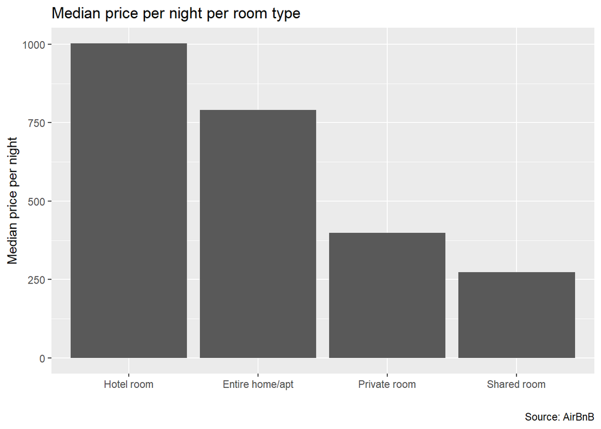

```r
#Price per night for each room type
median_per_roomtype %>%
  ggplot(aes(
    x = reorder(room_type, desc(median_price)),
    y = median_price
  )) +
  geom_col() +
  labs(
    title = "Median price per night per room type",
    x = "",
    y = "Median price per night",
    caption = "Source: AirBnB"
  )
```

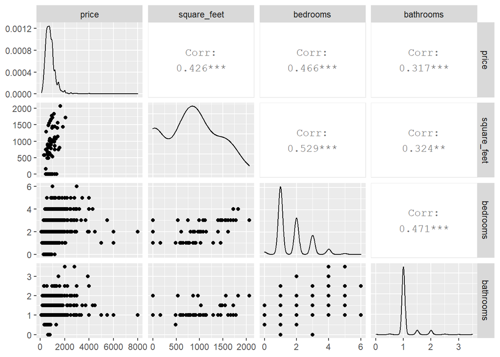

```r
listings<-listings%>%
  filter(minimum_nights == 4)

listings_matrix<- listings %>%
  select(price, square_feet ,bedrooms, bathrooms)

ggpairs(listings_matrix, columns = 1:4)
```

# REGRESSION

## Basic explanatory variables

```r
# already included above, can be deleted

# listings$price = as.numeric(gsub("[\\$,]", "", listings$price)) # make price into a numeric variable
# listings$cleaning_fee = as.numeric(gsub("[\\$,]", "", listings$cleaning_fee))
# listings$extra_people = as.numeric(gsub("[\\$,]", "", listings$extra_people))
# listings$guests_included = as.numeric(gsub("[\\$,]", "", listings$guests_included))

# do we still need this?
listings <- listings %>%
  mutate(cleaning_fee = case_when(
    is.na(cleaning_fee) ~ 0,
    TRUE ~ cleaning_fee
  ))

listings <- listings %>%
  mutate(price = case_when(
    is.na(price) ~ 0,
    TRUE ~ price
  ))

listings <- listings %>%
  mutate(extra_people = case_when(
    is.na(extra_people) ~ 0,
    TRUE ~ extra_people
  ))

listings <- listings %>%
  mutate(guests_included = case_when(
    is.na(guests_included) ~ 0,
    TRUE ~ guests_included
  ))



# create new variable for 4 nights using price, guests_included, cleaning_fee and extra_people
listings_new <- listings %>%
  mutate(price_4_nights =
           ifelse(guests_included <= 1,
                  (price + extra_people) * 4 + cleaning_fee,
                  (price) * 4 + cleaning_fee))

# delete?
#model_1<-lm(price_4_nights~cleaning_fee,data=listings_new)
#model_1 %>% tidy(conf.int=TRUE)
#model_1 %>% glance()
```

```r
# density plots for price_4_nights
density.default(listings_new$price_4_nights)
```

```
##
## Call:
##  density.default(x = listings_new$price_4_nights)
##
## Data: listings_new$price_4_nights (3117 obs.);   Bandwidth 'bw' = 251.3
##
##        x               y
##  Min.   : -354   Min.   :0.000e+00
##  1st Qu.: 7921   1st Qu.:1.143e-08
##  Median :16196   Median :5.099e-07
##  Mean   :16196   Mean   :3.018e-05
##  3rd Qu.:24471   3rd Qu.:7.252e-06
##  Max.   :32746   Max.   :2.979e-04
```

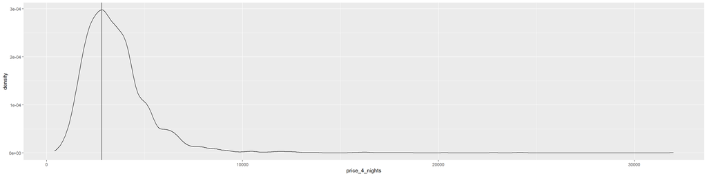

```r
# plot density of price_4_nights
ggplot(listings_new,aes(x=price_4_nights))+
  geom_density() +
  geom_vline(xintercept = density(listings_new$price_4_nights)$x[which.max(density(listings_new$price_4_nights)$y)]) # plot vertical line to show maximum value
```

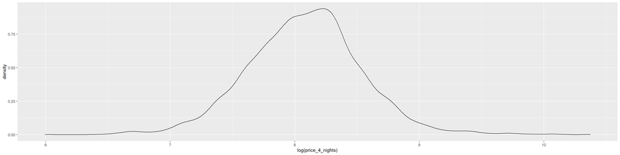

```r
# plot density of log(price_4_nights)
ggplot(listings_new,aes(x=log(price_4_nights)))+
  geom_density()
```

```r
# calculate maximum (most often?) occurring price for 4 nights
max_p4n<-density(listings_new$price_4_nights)$x[which.max(density(listings_new$price_4_nights)$y)]

max_p4n
```

```
## [1] 2819.998
```

### Model 1

Fitting a regression model called model1 with the following explanatory variables: prop_type_simplified, number_of_reviews, and review_scores_rating

```r
# create a new dataset with the new variable of log(price_4_nights)
listings_log <- listings_new %>%
  mutate(price_4_nights_log = log10(price_4_nights))


# create model1 of price_4_nights with explanatory variables prop_type_simplified, number_of_reviews and review_scores_ratings
model1<-lm(price_4_nights_log ~
              prop_type_simplified +
              number_of_reviews +
              review_scores_rating +
             NULL,
            data = listings_log)
model1 %>% tidy(conf.int=TRUE)
```

| term | estimate | std.error | statistic | p.value | conf.low | conf.high |
| --- | --- | --- | --- | --- | --- | --- |
| (Intercept) | 3.17 | 0.0601 | 52.7 | 0 | 3.05 | 3.29 |
| prop_type_simplifiedCondominium | 0.0314 | 0.0137 | 2.29 | 0.0219 | 0.00455 | 0.0582 |
| prop_type_simplifiedHouse | 0.17 | 0.0163 | 10.5 | 4.33e-25 | 0.138 | 0.202 |
| prop_type_simplifiedOther | 0.154 | 0.0289 | 5.34 | 1.01e-07 | 0.0977 | 0.211 |
| prop_type_simplifiedTownhouse | 0.198 | 0.0237 | 8.34 | 1.15e-16 | 0.151 | 0.245 |
| number_of_reviews | 0.000707 | 0.000203 | 3.48 | 0.000504 | 0.000309 | 0.0011 |
| review_scores_rating | 0.00319 | 0.000628 | 5.07 | 4.21e-07 | 0.00195 | 0.00442 |

```r
model1 %>% glance()
```

| r.squared | adj.r.squared | sigma | statistic | p.value | df | logLik | AIC | BIC | deviance | df.residual | nobs |
| --- | --- | --- | --- | --- | --- | --- | --- | --- | --- | --- | --- |
| 0.0833 | 0.0812 | 0.19 | 39.7 | 1.97e-46 | 6 | 641 | -1.27e+03 | -1.22e+03 | 94.3 | 2619 | 2626 |

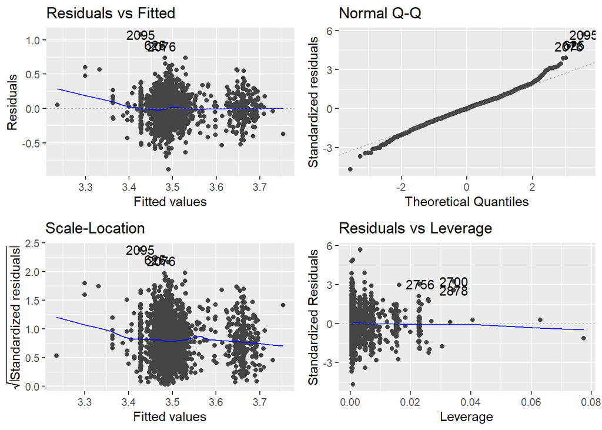

```r
# check residuals
autoplot(model1)
```

Model 1: 8%

### Model 2

We want to determine if room_type is a significant predictor of the cost for 4 nights, given everything else in the model.

```r
# create model2 by adding room_type to model1
model2<-lm(price_4_nights_log ~
             prop_type_simplified +
             number_of_reviews +
             review_scores_rating +
             room_type +
             NULL,
            data = listings_log)
model2 %>% tidy(conf.int=TRUE)
```

| term | estimate | std.error | statistic | p.value | conf.low | conf.high |
| --- | --- | --- | --- | --- | --- | --- |
| (Intercept) | 3.24 | 0.0555 | 58.4 | 0 | 3.13 | 3.35 |
| prop_type_simplifiedCondominium | 0.0223 | 0.0126 | 1.77 | 0.0775 | -0.00246 | 0.047 |
| prop_type_simplifiedHouse | 0.166 | 0.015 | 11.1 | 6.68e-28 | 0.137 | 0.196 |
| prop_type_simplifiedOther | 0.156 | 0.0266 | 5.84 | 6.01e-09 | 0.103 | 0.208 |
| prop_type_simplifiedTownhouse | 0.183 | 0.0219 | 8.38 | 8.31e-17 | 0.141 | 0.226 |
| number_of_reviews | 0.000904 | 0.000187 | 4.83 | 1.44e-06 | 0.000537 | 0.00127 |
| review_scores_rating | 0.00262 | 0.00058 | 4.52 | 6.55e-06 | 0.00148 | 0.00376 |
| room_typePrivate room | -0.307 | 0.0142 | -21.6 | 4.35e-95 | -0.335 | -0.279 |

```r
model2 %>% glance()
```

| r.squared | adj.r.squared | sigma | statistic | p.value | df | logLik | AIC | BIC | deviance | df.residual | nobs |
| --- | --- | --- | --- | --- | --- | --- | --- | --- | --- | --- | --- |
| 0.222 | 0.22 | 0.175 | 106 | 1.6e-137 | 7 | 856 | -1.69e+03 | -1.64e+03 | 80.1 | 2618 | 2626 |

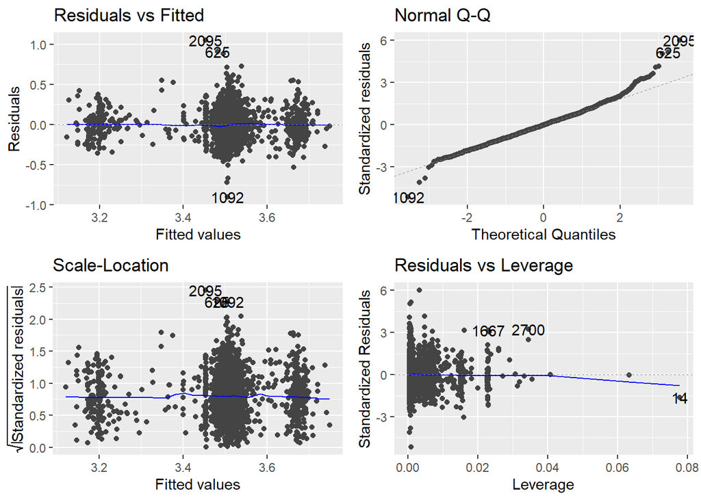

```r
# check residuals
autoplot(model2)
```

## Exploring additional explanatory variables

### Model 3

Are the number of bathrooms, bedrooms, beds, or size of the house (accomodates) significant predictors of price_4_nights?

```r
# create model3a by adding bathrooms, bedrooms, beds, accommodates to model2
model3a<-lm(price_4_nights_log ~
            prop_type_simplified +
             number_of_reviews +
             review_scores_rating +
             room_type +
             bathrooms +
             bedrooms +
             beds +
             accommodates +
             NULL,
            data = listings_log)
model3a %>% tidy(conf.int=TRUE)
```

| term | estimate | std.error | statistic | p.value | conf.low | conf.high |
| --- | --- | --- | --- | --- | --- | --- |
| (Intercept) | 2.99 | 0.0498 | 59.9 | 0 | 2.89 | 3.08 |
| prop_type_simplifiedCondominium | 0.00924 | 0.011 | 0.84 | 0.401 | -0.0123 | 0.0308 |
| prop_type_simplifiedHouse | -0.0294 | 0.015 | -1.95 | 0.0511 | -0.0588 | 0.000135 |
| prop_type_simplifiedOther | 0.0431 | 0.0238 | 1.81 | 0.07 | -0.00353 | 0.0897 |
| prop_type_simplifiedTownhouse | 0.0214 | 0.0201 | 1.06 | 0.287 | -0.018 | 0.0609 |
| number_of_reviews | 0.0011 | 0.000163 | 6.76 | 1.65e-11 | 0.000784 | 0.00142 |
| review_scores_rating | 0.00272 | 0.000506 | 5.37 | 8.47e-08 | 0.00173 | 0.00371 |
| room_typePrivate room | -0.226 | 0.0129 | -17.5 | 3.99e-65 | -0.252 | -0.201 |
| bathrooms | 0.0618 | 0.0132 | 4.67 | 3.24e-06 | 0.0358 | 0.0878 |
| bedrooms | 0.0659 | 0.00584 | 11.3 | 7.95e-29 | 0.0544 | 0.0773 |
| beds | 0.00368 | 0.00314 | 1.17 | 0.242 | -0.00249 | 0.00984 |
| accommodates | 0.0203 | 0.0036 | 5.63 | 1.95e-08 | 0.0132 | 0.0274 |

```r
model3a %>% glance()
```

| r.squared | adj.r.squared | sigma | statistic | p.value | df | logLik | AIC | BIC | deviance | df.residual | nobs |
| --- | --- | --- | --- | --- | --- | --- | --- | --- | --- | --- | --- |
| 0.411 | 0.409 | 0.152 | 166 | 1.03e-290 | 11 | 1.22e+03 | -2.42e+03 | -2.34e+03 | 60.5 | 2612 | 2624 |

```r
# test VIF
car::vif(model3a)
```

```
##                          GVIF Df GVIF^(1/(2*Df))
## prop_type_simplified 1.487421  4        1.050883
## number_of_reviews    1.013807  1        1.006880
## review_scores_rating 1.012978  1        1.006468
## room_type            1.093436  1        1.045675
## bathrooms            1.536573  1        1.239586
## bedrooms             3.269508  1        1.808178
## beds                 2.505434  1        1.582856
## accommodates         3.776561  1        1.943338
```

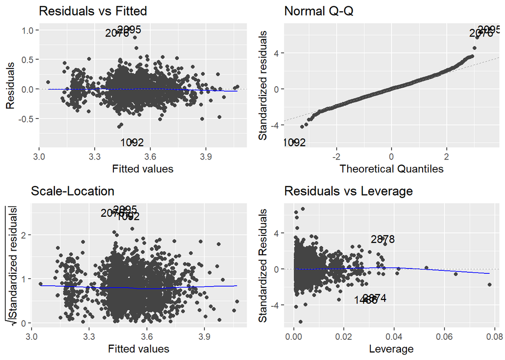

```r
# check residuals
autoplot(model3a)
```

However, the prop_type becomes not a significant predictor anymore, thus we will include it from the following analyses:

```r
# create model3 by removing prop_type from model3a
model3<-lm(price_4_nights_log ~
            # prop_type_simplified +
             number_of_reviews +
             review_scores_rating +
             room_type +
             bathrooms +
             bedrooms +
             # beds +
             accommodates +
             NULL,
            data = listings_log)
model3 %>% tidy(conf.int=TRUE)
```

| term | estimate | std.error | statistic | p.value | conf.low | conf.high |
| --- | --- | --- | --- | --- | --- | --- |
| (Intercept) | 2.99 | 0.0493 | 60.6 | 0 | 2.89 | 3.09 |
| number_of_reviews | 0.00113 | 0.000163 | 6.91 | 6.03e-12 | 0.000807 | 0.00145 |
| review_scores_rating | 0.0027 | 0.000506 | 5.33 | 1.06e-07 | 0.00171 | 0.00369 |
| room_typePrivate room | -0.227 | 0.0129 | -17.7 | 5.78e-66 | -0.253 | -0.202 |
| bathrooms | 0.0615 | 0.0125 | 4.94 | 8.23e-07 | 0.0371 | 0.086 |
| bedrooms | 0.0665 | 0.00563 | 11.8 | 1.75e-31 | 0.0555 | 0.0776 |
| accommodates | 0.0218 | 0.00326 | 6.7 | 2.61e-11 | 0.0154 | 0.0282 |

```r
model3 %>% glance()
```

| r.squared | adj.r.squared | sigma | statistic | p.value | df | logLik | AIC | BIC | deviance | df.residual | nobs |
| --- | --- | --- | --- | --- | --- | --- | --- | --- | --- | --- | --- |
| 0.409 | 0.407 | 0.152 | 302 | 3.07e-294 | 6 | 1.22e+03 | -2.42e+03 | -2.37e+03 | 60.9 | 2618 | 2625 |

```r
# test VIF
car::vif(model3)
```

```
##    number_of_reviews review_scores_rating            room_type
##             1.008640             1.010910             1.086347
##            bathrooms             bedrooms         accommodates
##             1.353722             3.024354             3.079850
```

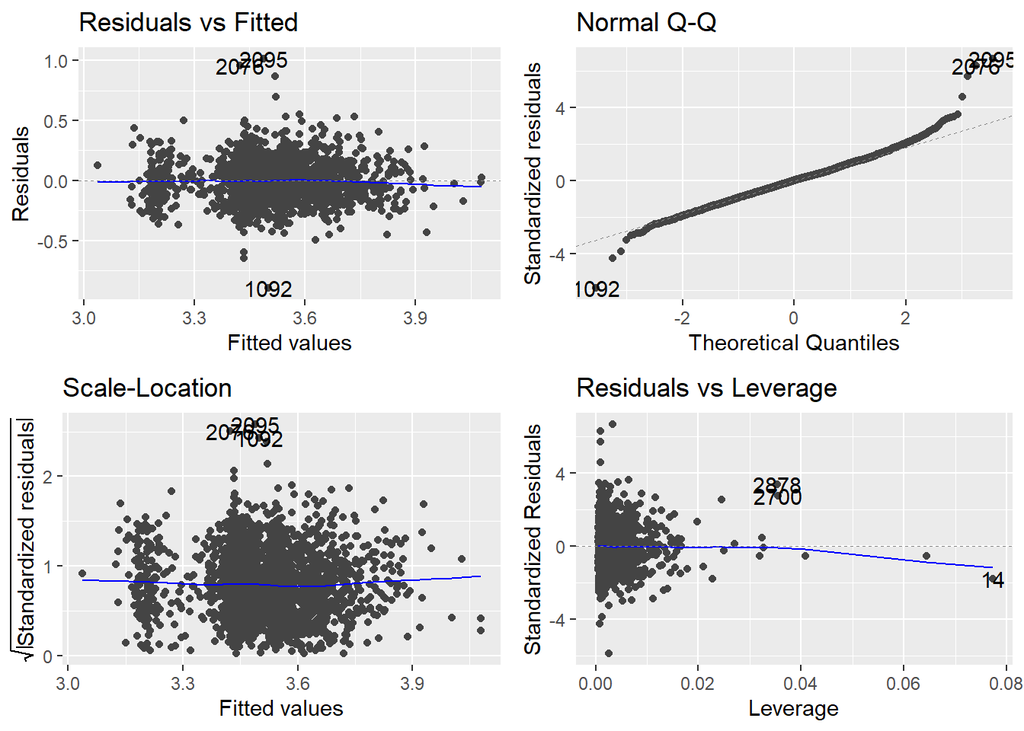

```r
# check residuals
autoplot(model3)
```

Model 3: 40%

### Model 4

Do superhosts command a pricing premium, after controlling for other variables?

```r
# delete this:
# typeof(listings_log$host_is_superhost)
#
# listings_log<-listings_log %>%
#   mutate(superhost = ifelse(host_is_superhost == TRUE, 1,0))


# create model4 by adding host_is_superhost to model3
model4<-lm(price_4_nights_log ~
            # prop_type_simplified +
             number_of_reviews +
             review_scores_rating +
             room_type +
             bathrooms +
             bedrooms +
             # beds +
             accommodates +
             host_is_superhost +
             NULL,
            data = listings_log)
model4 %>% tidy(conf.int=TRUE)
```

| term | estimate | std.error | statistic | p.value | conf.low | conf.high |
| --- | --- | --- | --- | --- | --- | --- |
| (Intercept) | 2.99 | 0.0495 | 60.5 | 0 | 2.9 | 3.09 |
| number_of_reviews | 0.00107 | 0.000174 | 6.14 | 9.56e-10 | 0.000729 | 0.00141 |
| review_scores_rating | 0.00266 | 0.000508 | 5.24 | 1.78e-07 | 0.00166 | 0.00366 |
| room_typePrivate room | -0.228 | 0.0129 | -17.7 | 4.06e-66 | -0.253 | -0.203 |
| bathrooms | 0.0616 | 0.0125 | 4.95 | 8.04e-07 | 0.0372 | 0.086 |
| bedrooms | 0.0666 | 0.00563 | 11.8 | 1.5e-31 | 0.0556 | 0.0777 |
| accommodates | 0.0218 | 0.00326 | 6.69 | 2.72e-11 | 0.0154 | 0.0282 |
| host_is_superhostTRUE | 0.0103 | 0.0114 | 0.906 | 0.365 | -0.012 | 0.0327 |

```r
model4 %>% glance()
```

| r.squared | adj.r.squared | sigma | statistic | p.value | df | logLik | AIC | BIC | deviance | df.residual | nobs |
| --- | --- | --- | --- | --- | --- | --- | --- | --- | --- | --- | --- |
| 0.409 | 0.407 | 0.152 | 259 | 3.69e-293 | 7 | 1.22e+03 | -2.41e+03 | -2.36e+03 | 60.8 | 2617 | 2625 |

```r
# test VIF
car::vif(model4)
```

```
##    number_of_reviews review_scores_rating            room_type
##             1.153953             1.018231             1.088815
##            bathrooms             bedrooms         accommodates
##             1.353762             3.025251             3.079970
##    host_is_superhost
##             1.160437
```

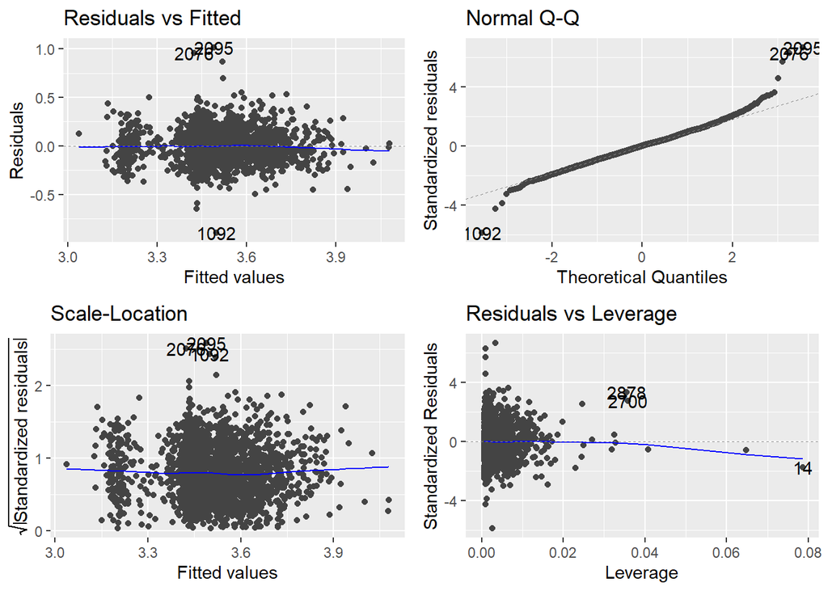

```r
# check residuals
autoplot(model4)
```

Since the p-value for the estimate of the superhost coefficient is not significant, it seems that superhosts do not command a price premium from their guests in Copenhagen.

### Model 5

Most owners advertise the exact location of their listing (is_location_exact == TRUE), while a non-trivial proportion don’t. After controlling for other variables, is a listing’s exact location a significant predictor of price_4_nights?

```r
# create model5 by adding is_location_exact == TRUE to model3
model5<-lm(price_4_nights_log ~
            # prop_type_simplified +
             number_of_reviews +
             review_scores_rating +
             room_type +
             bathrooms +
             bedrooms +
             # beds +
             accommodates +
             is_location_exact +
             NULL,
             data = listings_log)
model5 %>% tidy(conf.int=TRUE)
```

| term | estimate | std.error | statistic | p.value | conf.low | conf.high |
| --- | --- | --- | --- | --- | --- | --- |
| (Intercept) | 2.99 | 0.0497 | 60.2 | 0 | 2.9 | 3.09 |
| number_of_reviews | 0.00113 | 0.000163 | 6.92 | 5.71e-12 | 0.000809 | 0.00145 |
| review_scores_rating | 0.0027 | 0.000507 | 5.33 | 1.06e-07 | 0.00171 | 0.00369 |
| room_typePrivate room | -0.228 | 0.0129 | -17.7 | 5.71e-66 | -0.253 | -0.202 |
| bathrooms | 0.0615 | 0.0125 | 4.93 | 8.54e-07 | 0.037 | 0.0859 |
| bedrooms | 0.0666 | 0.00563 | 11.8 | 1.69e-31 | 0.0555 | 0.0776 |
| accommodates | 0.0218 | 0.00326 | 6.69 | 2.79e-11 | 0.0154 | 0.0282 |
| is_location_exactTRUE | -0.00287 | 0.00759 | -0.379 | 0.705 | -0.0178 | 0.012 |

```r
model5 %>% glance()
```

| r.squared | adj.r.squared | sigma | statistic | p.value | df | logLik | AIC | BIC | deviance | df.residual | nobs |
| --- | --- | --- | --- | --- | --- | --- | --- | --- | --- | --- | --- |
| 0.409 | 0.407 | 0.152 | 258 | 5.17e-293 | 7 | 1.22e+03 | -2.41e+03 | -2.36e+03 | 60.9 | 2617 | 2625 |

```r
# test VIF
car::vif(model5)
```

```
##    number_of_reviews review_scores_rating            room_type
##             1.009895             1.010912             1.086674
##            bathrooms             bedrooms         accommodates
##             1.354035             3.025309             3.080998
##    is_location_exact
##             1.002243
```

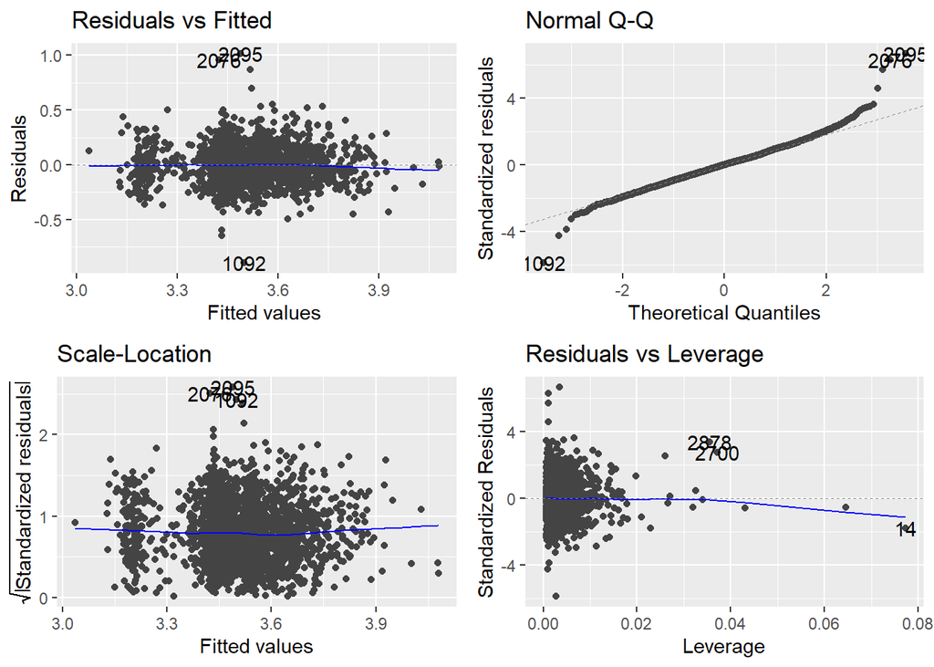

```r
# check residuals
autoplot(model5)
```

A listing’s exact location is not a significant predictor of price_4_nights, thus we will not include it in the following models

### Model 6

In order to reduce the number of neighbourhoods for our analysis we cluster the different neighbourhoods into groups, based on our experience, talking to locals, and research.

The city of Copenhagen has 10 official administrative districts. Additionally, there is Frederiksberg, which is an independent municipality and, thus, separate from the Copenhagen Municipality, however, it is still part of Copenhagen city.

Indre By is the city center of Copenhagen and will remain its own cluster “Center”.

All the residential neighbourhoods surrounding the city center are commonly grouped together, and since they all end in -bro, often referred to as -bro districts (Brokvaterer in Danish). Frederiksberg is often also included in the -bro districts. Hence, we will cluster these 4 Brokvaterer districts into one group of Brokvarterer

Additionally, the two Amager districts (Vest and Ost) are grouped together.

In the West, Valby, Vanlose and Brønshøj-Husum are summarized.

Lastly, Bispebjerg, often referred to as Nordvest, which is more of a residential neighbourhood, is its own cluster

```r
# create variable neighbourhood_simplified with 5 categories
listings_log <- listings_log %>%
  mutate(neighbourhood_simplified = case_when(
    neighbourhood_cleansed %in% c("Indre By") ~ "Center",
    neighbourhood_cleansed %in% c("Frederiksberg","Nrrebro", "sterbro","Vesterbro-Kongens Enghave") ~ "Brokvarterer",
    neighbourhood_cleansed %in% c("Amager st","Amager Vest") ~ "Amager",
    neighbourhood_cleansed %in% c("Brnshj-Husum","Valby", "Vanlose") ~ "West",
    TRUE ~ "Nordvest"
  ))

# create model6 by adding neighbourhood_simplified to model3
model6<-lm(price_4_nights_log ~
            prop_type_simplified +
             number_of_reviews +
             review_scores_rating +
             room_type +
             bathrooms +
             bedrooms +
             # beds +
             accommodates +
             neighbourhood_simplified +
             NULL,
             data = listings_log)
model6 %>% tidy(conf.int=TRUE)
```

| term | estimate | std.error | statistic | p.value | conf.low | conf.high |
| --- | --- | --- | --- | --- | --- | --- |
| (Intercept) | 3 | 0.0463 | 64.8 | 0 | 2.91 | 3.09 |
| prop_type_simplifiedCondominium | 0.0113 | 0.0101 | 1.12 | 0.265 | -0.00854 | 0.0311 |
| prop_type_simplifiedHouse | 0.0347 | 0.0144 | 2.41 | 0.0162 | 0.00644 | 0.063 |
| prop_type_simplifiedOther | 0.0639 | 0.0219 | 2.93 | 0.00346 | 0.0211 | 0.107 |
| prop_type_simplifiedTownhouse | 0.0317 | 0.0186 | 1.7 | 0.0885 | -0.00477 | 0.0682 |
| number_of_reviews | 0.000698 | 0.000151 | 4.63 | 3.85e-06 | 0.000402 | 0.000993 |
| review_scores_rating | 0.0023 | 0.000465 | 4.95 | 8.04e-07 | 0.00139 | 0.00321 |
| room_typePrivate room | -0.205 | 0.0119 | -17.2 | 3.96e-63 | -0.228 | -0.181 |
| bathrooms | 0.0571 | 0.0121 | 4.7 | 2.7e-06 | 0.0333 | 0.0809 |
| bedrooms | 0.0584 | 0.00523 | 11.2 | 2.5e-28 | 0.0481 | 0.0686 |
| accommodates | 0.0265 | 0.00301 | 8.8 | 2.5e-18 | 0.0206 | 0.0324 |
| neighbourhood_simplifiedBrokvarterer | 0.0391 | 0.00784 | 4.98 | 6.65e-07 | 0.0237 | 0.0545 |
| neighbourhood_simplifiedCenter | 0.165 | 0.0107 | 15.4 | 4.06e-51 | 0.144 | 0.186 |
| neighbourhood_simplifiedNordvest | -0.091 | 0.012 | -7.56 | 5.68e-14 | -0.115 | -0.0674 |
| neighbourhood_simplifiedWest | -0.0787 | 0.014 | -5.64 | 1.89e-08 | -0.106 | -0.0513 |

```r
model6 %>% glance()
```

| r.squared | adj.r.squared | sigma | statistic | p.value | df | logLik | AIC | BIC | deviance | df.residual | nobs |
| --- | --- | --- | --- | --- | --- | --- | --- | --- | --- | --- | --- |
| 0.506 | 0.503 | 0.14 | 191 | 0 | 14 | 1.45e+03 | -2.87e+03 | -2.78e+03 | 50.9 | 2610 | 2625 |

```r
# test VIF
car::vif(model6)
```

```
##                              GVIF Df GVIF^(1/(2*Df))
## prop_type_simplified     1.645580  4        1.064241
## number_of_reviews        1.028252  1        1.014028
## review_scores_rating     1.014851  1        1.007398
## room_type                1.101145  1        1.049355
## bathrooms                1.533926  1        1.238518
## bedrooms                 3.112263  1        1.764161
## accommodates             3.130869  1        1.769426
## neighbourhood_simplified 1.189265  4        1.021903
```

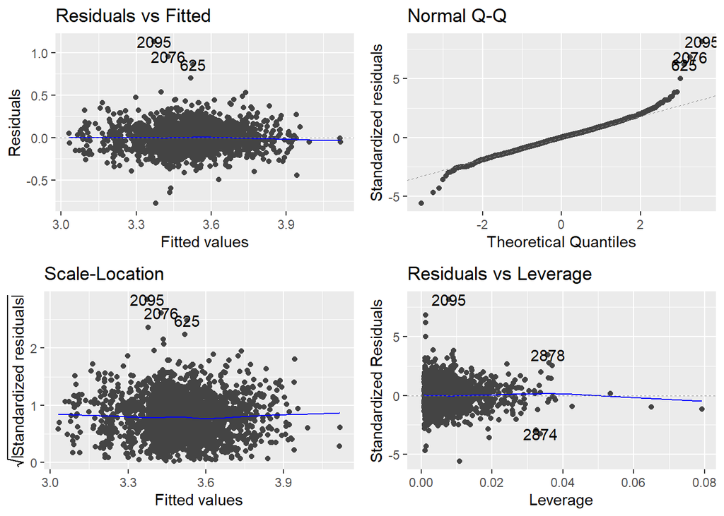

```r
# check residuals
autoplot(model6)
```

One can see that the neighbourhood of an apartment is an predictor of the price for 4 nights in Copenhagen.

Additionally, property_type became significant again in this model, so it will be included again in the following models.

Model 6: 50%

### Model 7

What is the effect of cancellation_policy on price_4_nights, after we control for other variables?

```r
# create model7 by adding cancellation_policy to model6
model7<-lm(price_4_nights_log ~
            prop_type_simplified +
             number_of_reviews +
             review_scores_rating +
             room_type +
             bathrooms +
             bedrooms +
             # beds +
             accommodates +
             neighbourhood_simplified +
             cancellation_policy +
             NULL,
             data = listings_log)
model7 %>% tidy(conf.int=TRUE)
```

| term | estimate | std.error | statistic | p.value | conf.low | conf.high |
| --- | --- | --- | --- | --- | --- | --- |
| (Intercept) | 3 | 0.0459 | 65.3 | 0 | 2.91 | 3.09 |
| prop_type_simplifiedCondominium | 0.01 | 0.01 | 0.997 | 0.319 | -0.00967 | 0.0297 |
| prop_type_simplifiedHouse | 0.0358 | 0.0143 | 2.5 | 0.0126 | 0.00769 | 0.0639 |
| prop_type_simplifiedOther | 0.0626 | 0.0217 | 2.88 | 0.00397 | 0.02 | 0.105 |
| prop_type_simplifiedTownhouse | 0.0285 | 0.0185 | 1.54 | 0.123 | -0.00774 | 0.0647 |
| number_of_reviews | 0.000563 | 0.000151 | 3.73 | 0.000198 | 0.000267 | 0.00086 |
| review_scores_rating | 0.00213 | 0.000462 | 4.61 | 4.19e-06 | 0.00122 | 0.00304 |
| room_typePrivate room | -0.202 | 0.0118 | -17.1 | 4.78e-62 | -0.225 | -0.179 |
| bathrooms | 0.0544 | 0.0121 | 4.52 | 6.6e-06 | 0.0308 | 0.0781 |
| bedrooms | 0.0566 | 0.0052 | 10.9 | 4.94e-27 | 0.0464 | 0.0668 |
| accommodates | 0.0266 | 0.00299 | 8.91 | 9.7e-19 | 0.0208 | 0.0325 |
| neighbourhood_simplifiedBrokvarterer | 0.0395 | 0.00779 | 5.07 | 4.16e-07 | 0.0242 | 0.0548 |
| neighbourhood_simplifiedCenter | 0.164 | 0.0106 | 15.4 | 3.7e-51 | 0.143 | 0.185 |
| neighbourhood_simplifiedNordvest | -0.0892 | 0.012 | -7.46 | 1.21e-13 | -0.113 | -0.0657 |
| neighbourhood_simplifiedWest | -0.0761 | 0.0139 | -5.49 | 4.39e-08 | -0.103 | -0.0489 |
| cancellation_policymoderate | 0.027 | 0.0065 | 4.15 | 3.46e-05 | 0.0142 | 0.0397 |
| cancellation_policystrict_14_with_grace_period | 0.043 | 0.00692 | 6.21 | 6.23e-10 | 0.0294 | 0.0565 |

```r
model7 %>% glance()
```

| r.squared | adj.r.squared | sigma | statistic | p.value | df | logLik | AIC | BIC | deviance | df.residual | nobs |
| --- | --- | --- | --- | --- | --- | --- | --- | --- | --- | --- | --- |
| 0.513 | 0.51 | 0.139 | 172 | 0 | 16 | 1.47e+03 | -2.91e+03 | -2.8e+03 | 50.1 | 2608 | 2625 |

```r
# test VIF
car::vif(model7)
```

```
##                              GVIF Df GVIF^(1/(2*Df))
## prop_type_simplified     1.651058  4        1.064683
## number_of_reviews        1.049124  1        1.024268
## review_scores_rating     1.018474  1        1.009195
## room_type                1.107658  1        1.052453
## bathrooms                1.535758  1        1.239257
## bedrooms                 3.121672  1        1.766825
## accommodates             3.135057  1        1.770609
## neighbourhood_simplified 1.192961  4        1.022300
## cancellation_policy      1.055378  2        1.013566
```

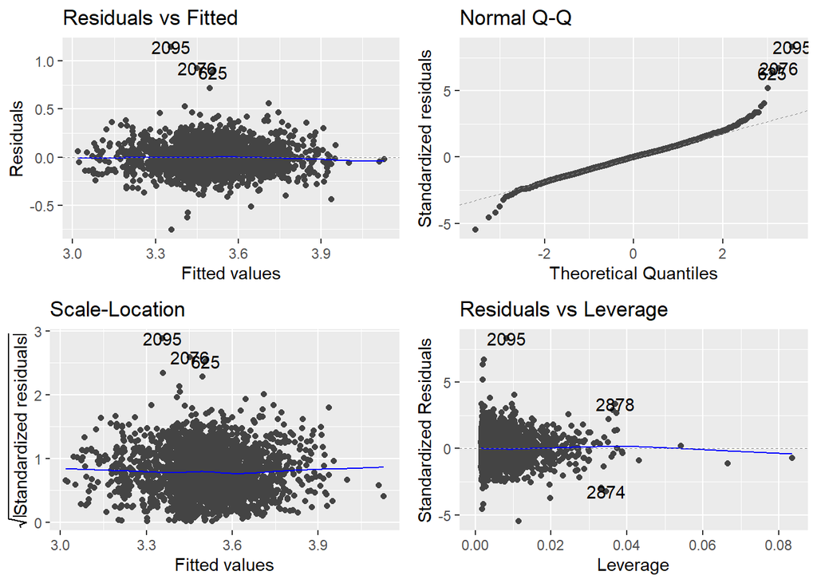

```r
# check residuals
autoplot(model7)
```

The cancellation policy is a significant predictor on price, with a flexible policy commanding the lowest price and with a strict policy commanding the highest price. This is surprising since usually hosts should be rewarded for the risk that they are taking with a flexibly cancellation policy. On the flipside, usually expensive and nice places have a stricter cancellation policy since they cannot afford to not have anyone live in their AirBnB. Thus, in the end the cancellation policy might rather be a consequence of the price and not a predictor of it.

# PREDICTION

## Selecting the best model

After creating all these models, we now find to find our best model, our final model for predictions.

Comparison of models

|  | (1) | (2) | (3) | (4) | (5) | (6) | (7) |
| --- | --- | --- | --- | --- | --- | --- | --- |
| (Intercept) | 3.171 | 3.243 | 2.990 | 2.994 | 2.993 | 3.000 | 3.000 |
|  | (0.060) | (0.056) | (0.049) | (0.049) | (0.050) | (0.046) | (0.046) |
| prop_type_simplifiedCondominium | 0.031 | 0.022 |  |  |  | 0.011 | 0.010 |
|  | (0.014) | (0.013) |  |  |  | (0.010) | (0.010) |
| prop_type_simplifiedHouse | 0.170 | 0.166 |  |  |  | 0.035 | 0.036 |
|  | (0.016) | (0.015) |  |  |  | (0.014) | (0.014) |
| prop_type_simplifiedOther | 0.154 | 0.156 |  |  |  | 0.064 | 0.063 |
|  | (0.029) | (0.027) |  |  |  | (0.022) | (0.022) |
| prop_type_simplifiedTownhouse | 0.198 | 0.183 |  |  |  | 0.032 | 0.028 |
|  | (0.024) | (0.022) |  |  |  | (0.019) | (0.018) |
| number_of_reviews | 0.001 | 0.001 | 0.001 | 0.001 | 0.001 | 0.001 | 0.001 |
|  | (0.000) | (0.000) | (0.000) | (0.000) | (0.000) | (0.000) | (0.000) |
| review_scores_rating | 0.003 | 0.003 | 0.003 | 0.003 | 0.003 | 0.002 | 0.002 |
|  | (0.001) | (0.001) | (0.001) | (0.001) | (0.001) | (0.000) | (0.000) |
| room_typePrivate room |  | -0.307 | -0.227 | -0.228 | -0.228 | -0.205 | -0.202 |
|  |  | (0.014) | (0.013) | (0.013) | (0.013) | (0.012) | (0.012) |
| bathrooms |  |  | 0.062 | 0.062 | 0.061 | 0.057 | 0.054 |
|  |  |  | (0.012) | (0.012) | (0.012) | (0.012) | (0.012) |
| bedrooms |  |  | 0.067 | 0.067 | 0.067 | 0.058 | 0.057 |
|  |  |  | (0.006) | (0.006) | (0.006) | (0.005) | (0.005) |
| accommodates |  |  | 0.022 | 0.022 | 0.022 | 0.026 | 0.027 |
|  |  |  | (0.003) | (0.003) | (0.003) | (0.003) | (0.003) |
| host_is_superhostTRUE |  |  |  | 0.010 |  |  |  |
|  |  |  |  | (0.011) |  |  |  |
| is_location_exactTRUE |  |  |  |  | -0.003 |  |  |
|  |  |  |  |  | (0.008) |  |  |
| neighbourhood_simplifiedBrokvarterer |  |  |  |  |  | 0.039 | 0.040 |
|  |  |  |  |  |  | (0.008) | (0.008) |
| neighbourhood_simplifiedCenter |  |  |  |  |  | 0.165 | 0.164 |
|  |  |  |  |  |  | (0.011) | (0.011) |
| neighbourhood_simplifiedNordvest |  |  |  |  |  | -0.091 | -0.089 |
|  |  |  |  |  |  | (0.012) | (0.012) |
| neighbourhood_simplifiedWest |  |  |  |  |  | -0.079 | -0.076 |
|  |  |  |  |  |  | (0.014) | (0.014) |
| cancellation_policymoderate |  |  |  |  |  |  | 0.027 |
|  |  |  |  |  |  |  | (0.007) |
| cancellation_policystrict_14_with_grace_period |  |  |  |  |  |  | 0.043 |
|  |  |  |  |  |  |  | (0.007) |
| #observations | 2626 | 2626 | 2625 | 2625 | 2625 | 2625 | 2625 |
| R squared | 0.083 | 0.222 | 0.409 | 0.409 | 0.409 | 0.506 | 0.513 |
| Adj. R Squared | 0.081 | 0.220 | 0.407 | 0.407 | 0.407 | 0.503 | 0.510 |
| Residual SE | 0.190 | 0.175 | 0.152 | 0.152 | 0.152 | 0.140 | 0.139 |

Model 7 is the best model with the highest R2 so this will be the final model.

## Final model

```r
final_model <- lm(price_4_nights_log ~
            prop_type_simplified +
             number_of_reviews +
             review_scores_rating +
             room_type +
             bathrooms +
             bedrooms +
             # beds +
             accommodates +
             neighbourhood_simplified +
             cancellation_policy +
             NULL,
             data = listings_log)
mosaic::msummary(final_model)
```

```
##                                                  Estimate Std. Error t value
## (Intercept)                                     3.0003225  0.0459346  65.317
## prop_type_simplifiedCondominium                 0.0099958  0.0100282   0.997
## prop_type_simplifiedHouse                       0.0357958  0.0143319   2.498
## prop_type_simplifiedOther                       0.0625539  0.0216954   2.883
## prop_type_simplifiedTownhouse                   0.0284892  0.0184766   1.542
## number_of_reviews                               0.0005633  0.0001511   3.727
## review_scores_rating                            0.0021308  0.0004621   4.612
## room_typePrivate room                          -0.2019976  0.0118304 -17.074
## bathrooms                                       0.0544444  0.0120574   4.515
## bedrooms                                        0.0565739  0.0051957  10.889
## accommodates                                    0.0266089  0.0029878   8.906
## neighbourhood_simplifiedBrokvarterer            0.0395175  0.0077876   5.074
## neighbourhood_simplifiedCenter                  0.1637088  0.0106447  15.379
## neighbourhood_simplifiedNordvest               -0.0891900  0.0119633  -7.455
## neighbourhood_simplifiedWest                   -0.0760729  0.0138551  -5.491
## cancellation_policymoderate                     0.0269644  0.0065002   4.148
## cancellation_policystrict_14_with_grace_period  0.0429572  0.0069197   6.208
##                                                Pr(>|t|)
## (Intercept)                                     < 2e-16 ***
## prop_type_simplifiedCondominium                0.318967
## prop_type_simplifiedHouse                      0.012564 *
## prop_type_simplifiedOther                      0.003968 **
## prop_type_simplifiedTownhouse                  0.123219
## number_of_reviews                              0.000198 ***
## review_scores_rating                           4.19e-06 ***
## room_typePrivate room                           < 2e-16 ***
## bathrooms                                      6.60e-06 ***
## bedrooms                                        < 2e-16 ***
## accommodates                                    < 2e-16 ***
## neighbourhood_simplifiedBrokvarterer           4.16e-07 ***
## neighbourhood_simplifiedCenter                  < 2e-16 ***
## neighbourhood_simplifiedNordvest               1.21e-13 ***
## neighbourhood_simplifiedWest                   4.39e-08 ***
## cancellation_policymoderate                    3.46e-05 ***
## cancellation_policystrict_14_with_grace_period 6.23e-10 ***
##
## Residual standard error: 0.1386 on 2608 degrees of freedom
##   (492 observations deleted due to missingness)
## Multiple R-squared:  0.5133, Adjusted R-squared:  0.5103
## F-statistic: 171.9 on 16 and 2608 DF,  p-value: < 2.2e-16
```

```r
get_regression_table(final_model)
```

| term | estimate | std_error | statistic | p_value | lower_ci | upper_ci |
| --- | --- | --- | --- | --- | --- | --- |
| intercept | 3 | 0.046 | 65.3 | 0 | 2.91 | 3.09 |
| prop_type_simplifiedCondominium | 0.01 | 0.01 | 0.997 | 0.319 | -0.01 | 0.03 |
| prop_type_simplifiedHouse | 0.036 | 0.014 | 2.5 | 0.013 | 0.008 | 0.064 |
| prop_type_simplifiedOther | 0.063 | 0.022 | 2.88 | 0.004 | 0.02 | 0.105 |
| prop_type_simplifiedTownhouse | 0.028 | 0.018 | 1.54 | 0.123 | -0.008 | 0.065 |
| number_of_reviews | 0.001 | 0 | 3.73 | 0 | 0 | 0.001 |
| review_scores_rating | 0.002 | 0 | 4.61 | 0 | 0.001 | 0.003 |
| room_typePrivate room | -0.202 | 0.012 | -17.1 | 0 | -0.225 | -0.179 |
| bathrooms | 0.054 | 0.012 | 4.51 | 0 | 0.031 | 0.078 |
| bedrooms | 0.057 | 0.005 | 10.9 | 0 | 0.046 | 0.067 |
| accommodates | 0.027 | 0.003 | 8.91 | 0 | 0.021 | 0.032 |
| neighbourhood_simplifiedBrokvarterer | 0.04 | 0.008 | 5.07 | 0 | 0.024 | 0.055 |
| neighbourhood_simplifiedCenter | 0.164 | 0.011 | 15.4 | 0 | 0.143 | 0.185 |
| neighbourhood_simplifiedNordvest | -0.089 | 0.012 | -7.46 | 0 | -0.113 | -0.066 |
| neighbourhood_simplifiedWest | -0.076 | 0.014 | -5.49 | 0 | -0.103 | -0.049 |
| cancellation_policymoderate | 0.027 | 0.007 | 4.15 | 0 | 0.014 | 0.04 |
| cancellation_policystrict_14_with_grace_period | 0.043 | 0.007 | 6.21 | 0 | 0.029 | 0.057 |

```r
get_regression_summaries(final_model)
```

| r_squared | adj_r_squared | mse | rmse | sigma | statistic | p_value | df | nobs |
| --- | --- | --- | --- | --- | --- | --- | --- | --- |
| 0.513 | 0.51 | 0.0191 | 0.138 | 0.139 | 172 | 0 | 16 | 2.62e+03 |

```r
vif(final_model)
```

```
##                              GVIF Df GVIF^(1/(2*Df))
## prop_type_simplified     1.651058  4        1.064683
## number_of_reviews        1.049124  1        1.024268
## review_scores_rating     1.018474  1        1.009195
## room_type                1.107658  1        1.052453
## bathrooms                1.535758  1        1.239257
## bedrooms                 3.121672  1        1.766825
## accommodates             3.135057  1        1.770609
## neighbourhood_simplified 1.192961  4        1.022300
## cancellation_policy      1.055378  2        1.013566
```